# Did Levels of Prior Medical Care Correlate with Health Outcomes in the Covid-19 Pandemic

Sam Kevy, 917191015

## Introduction

The primary question of interest is whether the level of access to medical care, as measured by the number of anual doctors' consultations per capita, prior to the outbreak of the COVID-19 pandemic, had an effect on a particular country's cumulative number of COVID-19 cases in 2020. A secondary question of interest is whether a country's Gross Domestic Product (GDP) per capita, was predictive of cumulative COVID-19 cases in that country in 2020. In addition, the report includes cumulative number of COVID-19 deaths per capita as an alternative dependent variable which could measure whether nations with more frequent medical interaction prior to the pandemic saw more positive health outcomes. This analysis seeks to measure if countries which had more robust health care systems that allowed citizens to see doctors more frequently saw fewer COVID-19 cases. In addition, the report could indicate whether wealthier nations, which may have larger health care systems and more resources, experienced fewer COVID-19 cases.

These questions were motivated by disparities in national health care systems both between wealthier and poorer nations, and between individual wealthy nations which use privatized or public forms of healthcare. The aim of this project was to see if there was any detectable difference in the COVID-19 infection rate between countries with different health care systems, measured by the average number of doctors' consulations. We hypothesize that there is a negative linear correlation between per capita COVID-19 cases in 2020 and anual number of doctors' consultations per capita, and GDP per capita. In other words, we expect linear modeling to reveal that countries with a population that visits the doctor frequently, and whos GDP per capita is higher, experienced fewer cases of COVID-19 than countries with less frequent medical appointments and lower GDP. Likewise, we hypothesis that there will be a negative linear relationship between per capita COVID-19 deaths, per capita docotors visits, and per capita GDP.

COVID-19 case data was obtained from the World Health Organization's (WHO) COVID-19 Dashboard which reports per country data on the daily number of new COVID-19 cases, cumulative COVID-19 cases, and cumulative deaths due to COVID-19. Data measuring the variable anual number of doctors' consultations per capita came from The Organisation for Economic Co-operation and Development (OECD). Data for the variable Gross Domestic Product per capita was collected from The World Bank, an international banking organization.

## Background

Covid-19 is a highly transmissable virus which originated in December of 2019 in Wuhan, China. It spread around the globe, infecting around 420 million people in just over 2 years, killing 5.86 million by March of 2022. The elderly, and those with pre-existing illnesses and auto-immune issues have been most at risk of death and significant ailements.

COVID-19 case data was obtained from the World Health Organization's (WHO) COVID-19 Dashboard which reports per country data on the daily number of new COVID-19 cases, cumulative COVID-19 cases, and cumulative deaths due to COVID-19. Begining on the 31 December 2019 the WHO recorded laboratory confirmed COVID-19 cases and deaths from 237 countries and territories, reported by official comuinications from the countries themselves, and veryified using public health websites. However the WHO warns that data is subject to variation in case detection, definitions, lab testing, and reporting strategies, all of which might skew the data. If certain countries under report infection data, then any predictive modeling will be skewed, and inaplicable to reality.

The dependent variables COVID-19 cases and deaths per capita were obtained by dividing the per country cumulative case and death numbers by the country's population. Using varaibles in the form of per capita ratios, ensures comparitability of cumulative case numbers while accounting for differences in country population. COVID-19 data is often reported as number of cases or deaths per 10,000 people, however all other varaibles in this analysis, namely GDP and anual doctors' consultations are per capita ratios, therefore it is simplier to keep all variables under the same ratio.

The WHO dataset was then combined with data measuring the variable anual number of doctors' consultations per capita, from The Organisation for Economic Co-operation and Development (OECD). The OECD recorded this data for 41 countries, with the source of the data varrying between countries. In some cases OECD conducted random polling to determine how often citizens had a consulation, in others the OECD recieved official data from hospital and physicain adminstration. This data comes from a range of years, primarily from 2019, however some data, like that of the United States, is from 2011. Ideally all data would be from the same year, however as a database which measures such a niche variable is rare, this database must be used. Anual number of doctors' consultations per capita refers to the number of consultations patients have with doctors in a given year in a particular country, divided by that countries population. Consultations refers to any contact with a physician for the purpose of medical care.

The final addition to the dataset was data for the variable Gross Domestic Product per capita, which was collected from The World Bank, an international banking organization, which monitors many dimensions of international finance including GDP. GDP refers to the total market value of all goods and services, measuring domestic production and economic health. A country's GDP per capita indicates the total wealth a country produces divided by the countries population, giving the relative wealth of an individual citizen. GDP is calculated by measuring the value added by all resident producers in a country. The World Bank's country management units collect this data in addition to obtaining data from official sources, like national governments. However, GDP is not a perfect measure of economic health, which limits the interpretation of any such correlation between GDP and COVID-19 outcomes. In addition, the World Bank warns the statistical offices in developing countries may face budget, training and time restrictions which jeopardizes the accuracy of the GDP. The World Bank does check this data with other sources, therefore sampling error is likely low.

Some similar research has been conducted. In 2021 a research paper (Tchicaya et al, 2021) investigated the spatial relationship between cumulative COVID-19 cases and serveral health service factors, health risk factors, and socio-spatial factors with the country of France. Researchers found a correlation between the density of physicians, and the mortality rate, indicating that regions with more doctors actually saw a higher mortality rate than regions with fewer doctors.

Another study (Mattiuzi et al, 2021) found that "total healthcare expenditure, public sector health expenditure" had no significant correlation with the COVID-19 death rate for countries within the European Union. This indicates that the funding of national healthcare systems may not be the most influential factor in the variance of the COVID-19 mortality rate. However, their findings conflicted with the aforementioned study, as analysis discovered that the mortality rate decreased in EU countries with large numbers of available physicians and hospitals. Our own analysis is still necessary, as these studies measure how the number of physicians during the pandemic impacted COVID-19 outcomes, while this analysis will examin how the frequency of medical appointments before the pandemic impacted a populations infection and mortality rate.

## Descriptive Analysis

```r
full = read.csv("./ProjectData/fullset.csv")
```

```r
fullset = full[,-c(2,4,5,9)]
fullset
```

A data.frame: 41 × 10

| iso3c <chr> | code <chr> | country <chr> | year <int> | value <dbl> | deaths_per_capita <dbl> | cases_per_capita <dbl> | GDP_per_capita <dbl> | Region <int> | fatality <dbl> |
| --- | --- | --- | --- | --- | --- | --- | --- | --- | --- |
| AUS | AU | Australia | 2019 | 7.3 | 3.538749e-05 | 0.0011036694 | 51692.843 | 1 | 0.032063492 |
| AUT | AT | Austria | 2019 | 6.6 | 7.015651e-04 | 0.0395953665 | 48586.801 | 1 | 0.017718364 |
| BEL | BE | Belgium | 2019 | 7.3 | 1.703358e-03 | 0.0559395265 | 45159.348 | 1 | 0.030449990 |
| BRA | BR | Brazil | 2013 | 2.8 | 9.012539e-04 | 0.0353069903 | 6796.845 | 3 | 0.025526218 |
| CAN | CA | Canada | 2019 | 6.6 | 4.005237e-04 | 0.0147101828 | 43258.176 | 2 | 0.027227652 |
| CHE | CH | Switzerland | 2017 | 4.3 | 8.596838e-04 | 0.0517499574 | 87097.036 | 1 | 0.016612262 |
| CHL | CL | Chile | 2019 | 2.9 | 8.625141e-04 | 0.0315954905 | 13231.704 | 3 | 0.027298646 |
| COL | CO | Colombia | 2019 | 2.6 | 8.327751e-04 | 0.0315195774 | 5334.556 | 1 | 0.026420885 |
| CRI | CR | Costa Rica | 2019 | 2.3 | 4.208779e-04 | 0.0325399078 | 12140.854 | 3 | 0.012934207 |
| CZE | CZ | Czechia | 2019 | 8.2 | 1.097029e-03 | 0.0656526617 | 22932.225 | 1 | 0.016709590 |
| DEU | DE | Germany | 2019 | 9.8 | 3.857136e-04 | 0.0202687934 | 46208.429 | 1 | 0.019029923 |
| DNK | DK | Denmark | 2019 | 4.0 | 2.201871e-04 | 0.0278788779 | 61063.316 | 1 | 0.007897990 |
| ESP | ES | Spain | 2017 | 7.3 | 1.136520e-03 | 0.0407017364 | 27063.194 | 1 | 0.027923131 |
| EST | EE | Estonia | 2019 | 5.5 | 1.697899e-04 | 0.0204769593 | 23027.027 | 1 | 0.008291752 |
| FIN | FI | Finland | 2019 | 4.4 | 1.063153e-04 | 0.0065394752 | 48773.281 | 1 | 0.016257465 |
| FRA | FR | France | 2018 | 5.9 | 9.452368e-04 | 0.0380404188 | 39030.360 | 1 | 0.024848221 |
| GBR | GB | United Kingdom | 2009 | 5.0 | 1.107665e-03 | 0.0369103353 | 41124.535 | 1 | 0.030009605 |
| GRC | GR | Greece | 2019 | 3.2 | 4.414146e-04 | 0.0128410593 | 17622.541 | 1 | 0.034375250 |
| HUN | HU | Hungary | 2019 | 10.7 | 9.671004e-04 | 0.0327744377 | 15980.741 | 1 | 0.029507766 |
| IRL | IE | Ireland | 2019 | 5.8 | 4.542794e-04 | 0.0176980750 | 85267.765 | 1 | 0.025668292 |
| ISL | IS | Iceland | 2014 | 5.9 | 7.914307e-05 | 0.0156839735 | 59270.180 | 1 | 0.005046111 |
| ISR | IL | Israel | 2019 | 8.2 | 3.603164e-04 | 0.0449027330 | 44168.944 | 5 | 0.008024375 |
| ITA | IT | Italy | 2019 | 10.4 | 1.226265e-03 | 0.0347161601 | 31714.221 | 1 | 0.035322592 |
| JPN | JP | Japan | 2018 | 12.5 | 2.661400e-05 | 0.0018007245 | 40193.252 | 4 | 0.014779608 |
| KOR | KR | South Korea | 2019 | 17.2 | 1.697548e-05 | 0.0011540041 | 31631.469 | 4 | 0.014710066 |
| LTU | LT | Lithuania | 2019 | 9.5 | 6.251118e-04 | 0.0507224389 | 20233.641 | 1 | 0.012324167 |
| LUX | LU | Luxembourg | 2019 | 5.5 | 7.702345e-04 | 0.0727673876 | 116014.602 | 1 | 0.010584886 |
| LVA | LV | Latvia | 2019 | 6.1 | 3.171101e-04 | 0.0198133310 | 17726.253 | 1 | 0.016004884 |
| MEX | MX | Mexico | 2019 | 2.3 | 1.137430e-03 | 0.0114786039 | 8329.271 | 2 | 0.099091332 |
| NLD | NL | Netherlands | 2019 | 8.8 | 6.412999e-04 | 0.0445168747 | 52397.117 | 1 | 0.014405770 |
| NOR | NO | Norway | 2019 | 4.4 | 7.974756e-05 | 0.0091354640 | 67389.912 | 1 | 0.008729448 |
| NZL | NZ | New Zealand | 2017 | 3.8 | 4.917098e-06 | 0.0003532443 | 41441.467 | 7 | 0.013919822 |
| POL | PL | Poland | 2019 | 7.7 | 7.405904e-04 | 0.0338069799 | 15720.995 | 1 | 0.021906435 |
| PRT | PT | Portugal | 2012 | 4.1 | 6.550830e-04 | 0.0388141784 | 22176.297 | 1 | 0.016877416 |
| RUS | RU | Russia | 2019 | 9.9 | 3.915642e-04 | 0.0217311682 | 10294.627 | 1 | 0.018018553 |
| SVK | SK | Slovakia | 2019 | 11.1 | 3.782864e-04 | 0.0317335574 | 19266.514 | 1 | 0.011920706 |
| SVN | SI | Slovenia | 2019 | 6.7 | 1.392297e-03 | 0.0559028363 | 25517.331 | 1 | 0.024905667 |
| SWE | SE | Sweden | 2019 | 2.6 | 9.250064e-04 | 0.0413802482 | 52274.409 | 1 | 0.022353814 |
| TUR | TR | Turkey | 2019 | 9.8 | 2.417385e-04 | 0.0258312082 | 8536.433 | 1 | 0.009358389 |
| USA | US | United States | 2011 | 4.0 | 1.057653e-03 | 0.0587952792 | 63413.514 | 2 | 0.017988747 |
| ZAF | ZA | South Africa | 2012 | 2.5 | 4.648223e-04 | 0.0172226195 | 5655.868 | 6 | 0.026989058 |

For the purpose of this analysis, we will only examine Covid-19 cases in the year 2020. Because governmental responses to the pandemic change overtime, as well as access to medication, vaccinations, and the infection rate of the dominant strain of COVID-19, issolating data from a single year helps reduce variation. There were 55,471,813 global cases in 2020, 1,298,019 deaths, with a case mortality rate of 0.023 or 2.3%.

This analysis will primarily use four variables, Cases per Capita, Deaths per Capita, Yearly Doctors' Consultations per Capita (labeled as Value in the table), and GDP per Capita. Deaths per Capita is included as another possible response varibale to see if the independent variables have a different correlation. However there are are several other variables while not included in the primary question of interest are useful in analysis. These are: Country Region, and Fatality Rate (number of deaths/number of cases, per country). These additional variables can be used to examine whether cases per capita differ between region as how countries respond to the crisis is related to the response of their neighboring countries. Fatality rate shows how likely was COVID-19 to lead to the death of someone infected, which could vary per country if the level of medical care varried.

### The Four Major Variables

```r
library(ggplot2)
library(dplyr)
require(maps)
require(viridis)
```

```r
fullset=   mutate(fullset,
    country = ifelse(country == "United States", "USA", country)
    )
```

#### Visualizing the Variables on a Map

```r
world_map <- map_data("world")
world_map$country = world_map$region
life.exp.map <- left_join(fullset, world_map, by = "country")
```

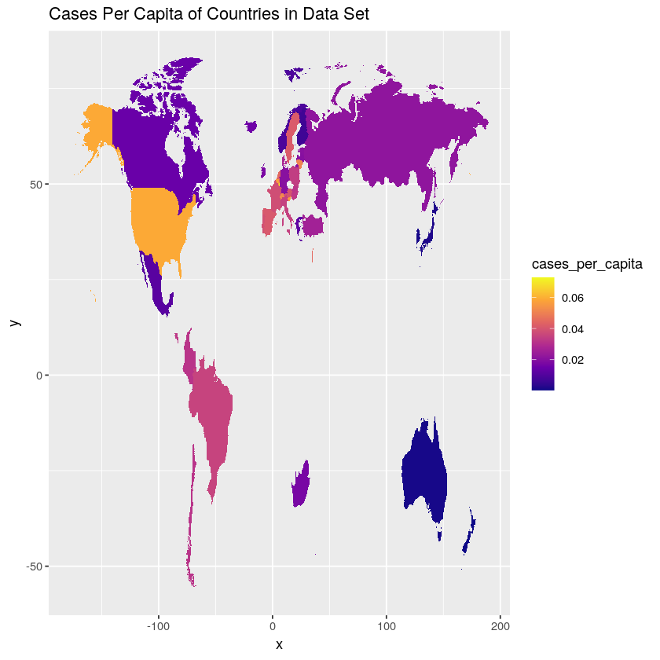

```r
ggplot(life.exp.map, aes(map_id = country, fill = cases_per_capita))+
  geom_map(map = life.exp.map)+
  expand_limits(x = life.exp.map$long, y = life.exp.map$lat)+
  scale_fill_viridis_c(option = "C")+  ggtitle('Cases Per Capita of Countries in Data Set')
```

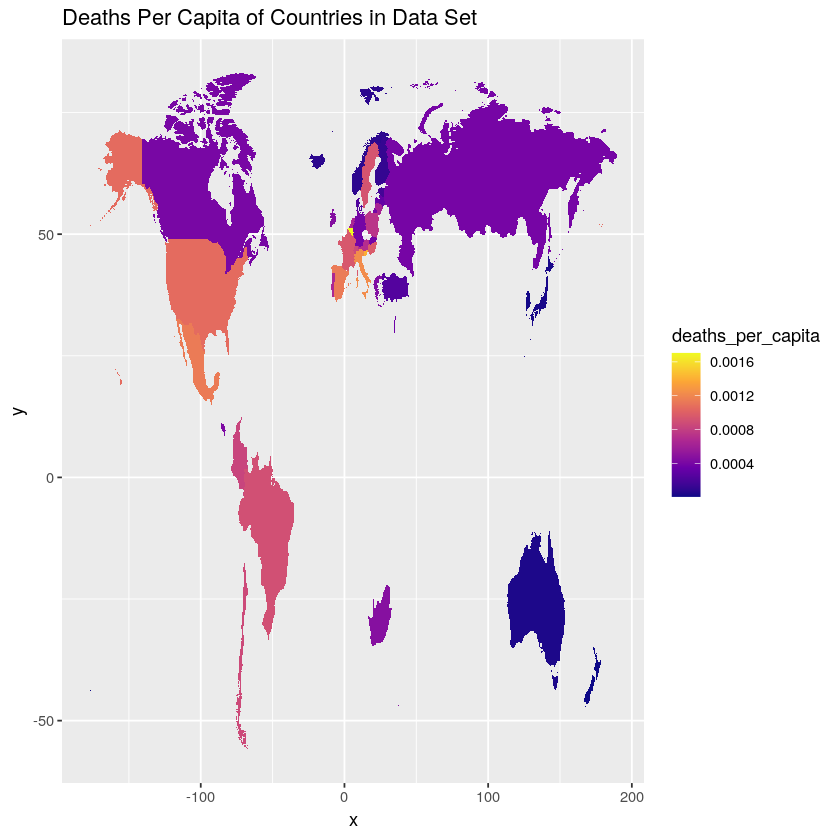

```r
ggplot(life.exp.map, aes(map_id = country, fill = deaths_per_capita))+
  geom_map(map = life.exp.map)+
  expand_limits(x = life.exp.map$long, y = life.exp.map$lat)+
  scale_fill_viridis_c(option = "C")+  ggtitle('Deaths Per Capita of Countries in Data Set')
```

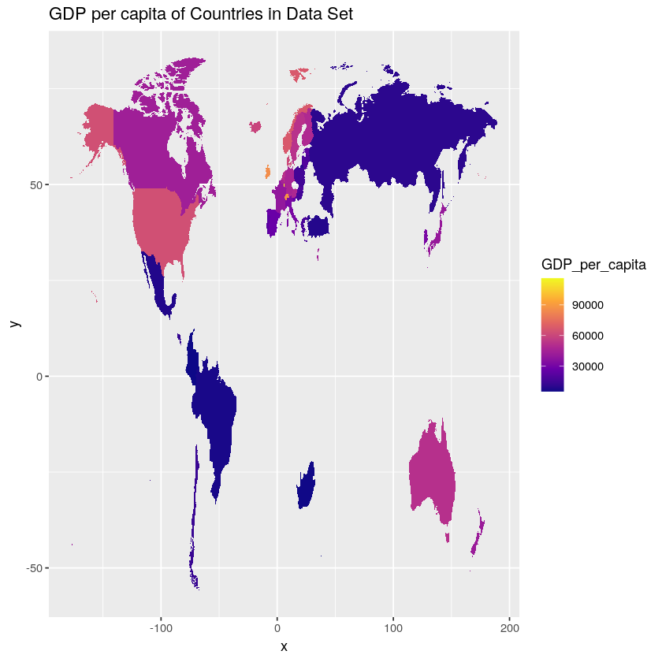

```r
ggplot(life.exp.map, aes(map_id = country, fill = GDP_per_capita))+
  geom_map(map = life.exp.map)+
  expand_limits(x = life.exp.map$long, y = life.exp.map$lat)+
  scale_fill_viridis_c(option = "C")+  ggtitle('GDP per capita of Countries in Data Set')
```

The above tables display which countries are represented in the dataset. 41 countries in total are represented, with the majority coming from Europe. From the map, we can see a clear bias towards data from the Northern Hemisphere, however this could reduce variation by limiting the data to countries with more similarities to each other.

### Descriptive Statistics

```r
summary(fullset[,c(5:8)])
```

```
     value        deaths_per_capita   cases_per_capita    GDP_per_capita
 Min.   : 2.300   Min.   :4.917e-06   Min.   :0.0003532   Min.   :  5335
 1st Qu.: 4.000   1st Qu.:3.171e-04   1st Qu.:0.0172226   1st Qu.: 17623
 Median : 5.900   Median :6.251e-04   Median :0.0317336   Median : 31714
 Mean   : 6.476   Mean   :6.166e-04   Mean   :0.0303928   Mean   : 36458
 3rd Qu.: 8.200   3rd Qu.:9.250e-04   3rd Qu.:0.0407017   3rd Qu.: 48773
 Max.   :17.200   Max.   :1.703e-03   Max.   :0.0727674   Max.   :116015
```

#### Standard Deviation of the Variables

```r
sapply(fullset[,c(5:8)], sd, na.rm=TRUE)
```

**value**

3.26104128215244

**deaths_per_capita**

0.000424844280214138

**cases_per_capita**

0.0182430687422276

**GDP_per_capita**

24790.1787063191

#### Visualizing Variables in Boxplot Form

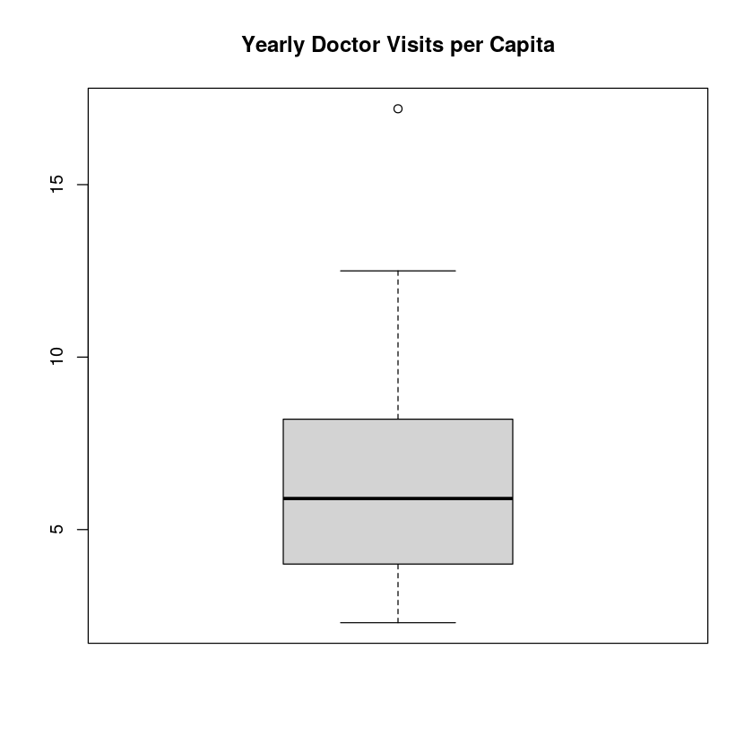

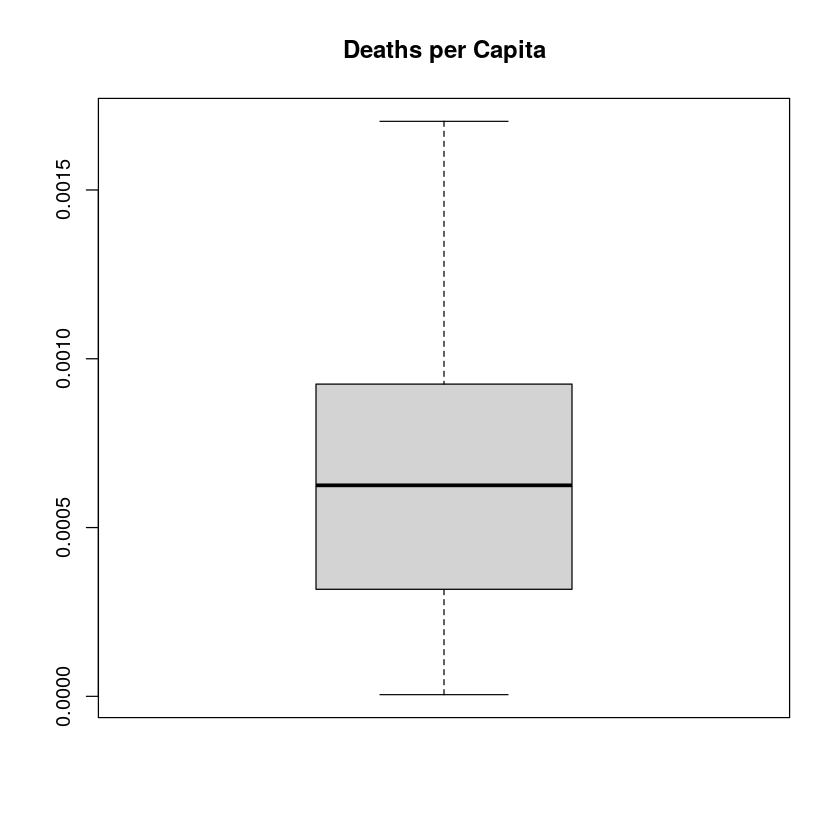

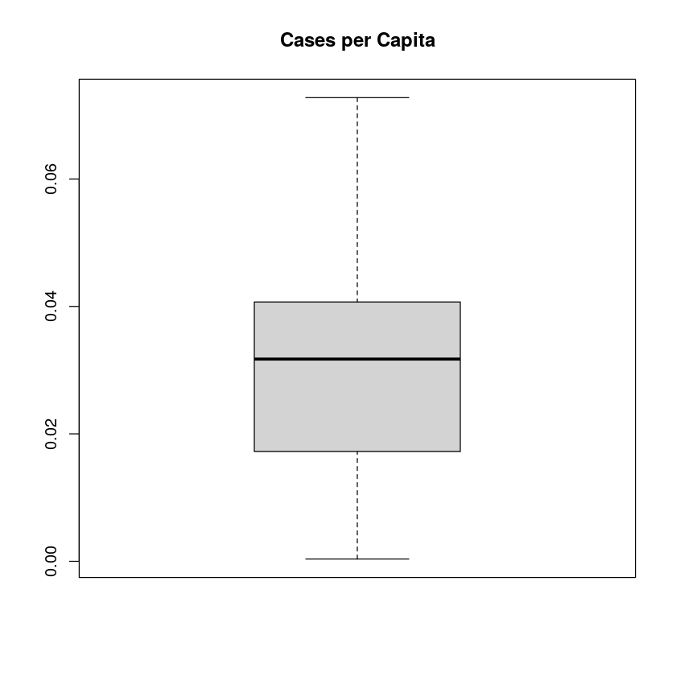

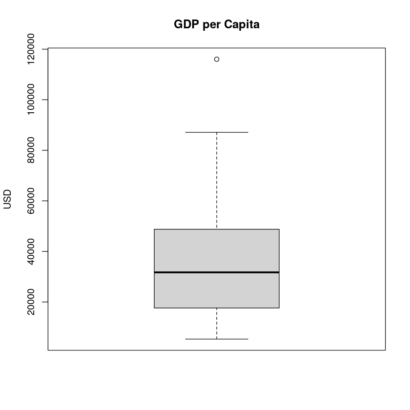

```r
boxplot(fullset$value, main = "Yearly Doctor Visits per Capita")
boxplot(fullset$deaths_per_capita, main = "Deaths per Capita")
boxplot(fullset$cases_per_capita, main = "Cases per Capita")
boxplot(fullset$GDP_per_capita, main = "GDP per Capita", ylab = "USD")
```

```r
fullset[which.max(fullset$value),]
```

A data.frame: 1 × 10

|  | iso3c <chr> | code <chr> | country <chr> | year <int> | value <dbl> | deaths_per_capita <dbl> | cases_per_capita <dbl> | GDP_per_capita <dbl> | Region <int> | fatality <dbl> |
| --- | --- | --- | --- | --- | --- | --- | --- | --- | --- | --- |
| 25 | KOR | KR | South Korea | 2019 | 17.2 | 1.697548e-05 | 0.001154004 | 31631.47 | 4 | 0.01471007 |

```r
fullset[which.max(fullset$GDP_per_capita),]
```

A data.frame: 1 × 10

|  | iso3c <chr> | code <chr> | country <chr> | year <int> | value <dbl> | deaths_per_capita <dbl> | cases_per_capita <dbl> | GDP_per_capita <dbl> | Region <int> | fatality <dbl> |
| --- | --- | --- | --- | --- | --- | --- | --- | --- | --- | --- |
| 27 | LUX | LU | Luxembourg | 2019 | 5.5 | 0.0007702345 | 0.07276739 | 116014.6 | 1 | 0.01058489 |

### Visualizing Relationships Between Four Main Variables

#### Scatterplot:

```r
library('ggplot2')
```

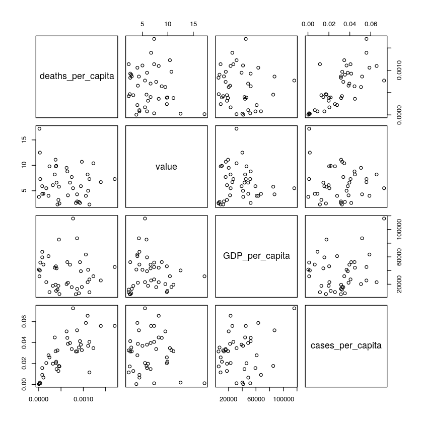

```r
plot(fullset[,c("deaths_per_capita",'value','GDP_per_capita','cases_per_capita')])
```

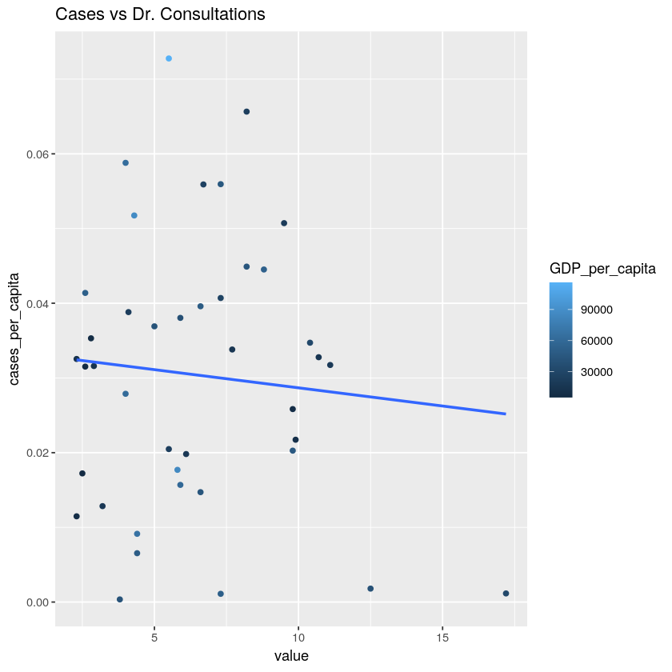

```r
ggplot(fullset,aes(y=cases_per_capita,x=value,color=GDP_per_capita))+geom_point()+stat_smooth(method="lm",se=FALSE) +ggtitle("Cases vs Dr. Consultations")
```

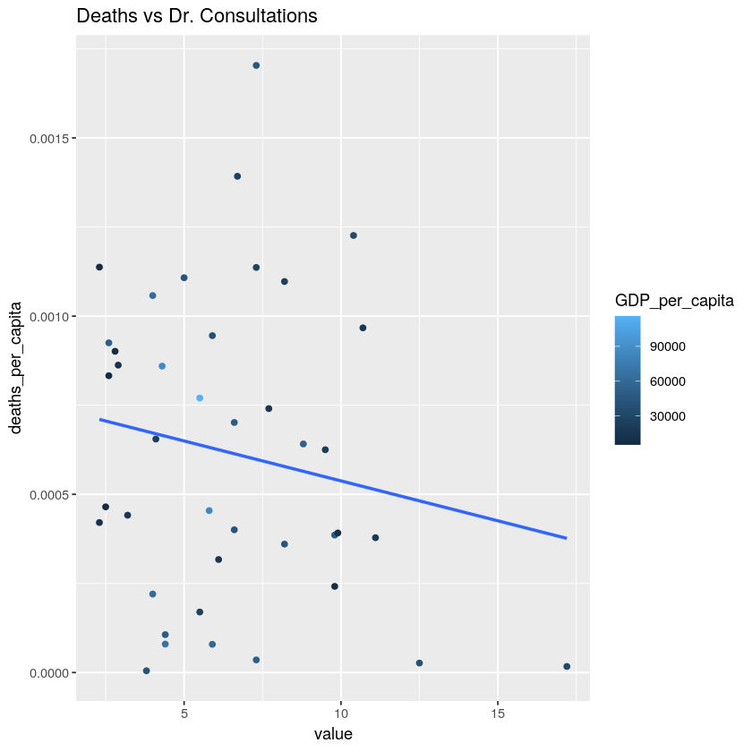

```r
ggplot(fullset,aes(y=deaths_per_capita,x=value,color=GDP_per_capita))+geom_point()+stat_smooth(method="lm",se=FALSE) +ggtitle("Deaths vs Dr. Consultations")
```

As we can see from the dot plot, there appears to be a significant linear relationship between deaths per capita and cases per capita which can be expected. However, there seems to be little correlation between cases per capita and represents average anual doctor visits, or GDP per capita. Visually this contradicts the hypothesis that there would be a negative correlation between cases and visits or GDP. This possible correlation, or lack there of will be explored in inferential analysis. Here we include the plot of the interaction between anual doctor visits and GDP per capita, as we hypothesize that as GDP per capita increases, acess to medical care increases as well, which might have some effect on COVID-19 cases or deaths. Likewise, the effect of doctors' consultations might be larger in countries which can provide more medical resources. However from the plot, we can see little evidence of correlation between the two variables.

### Additional Variables

#### Exploring the Impact of Region

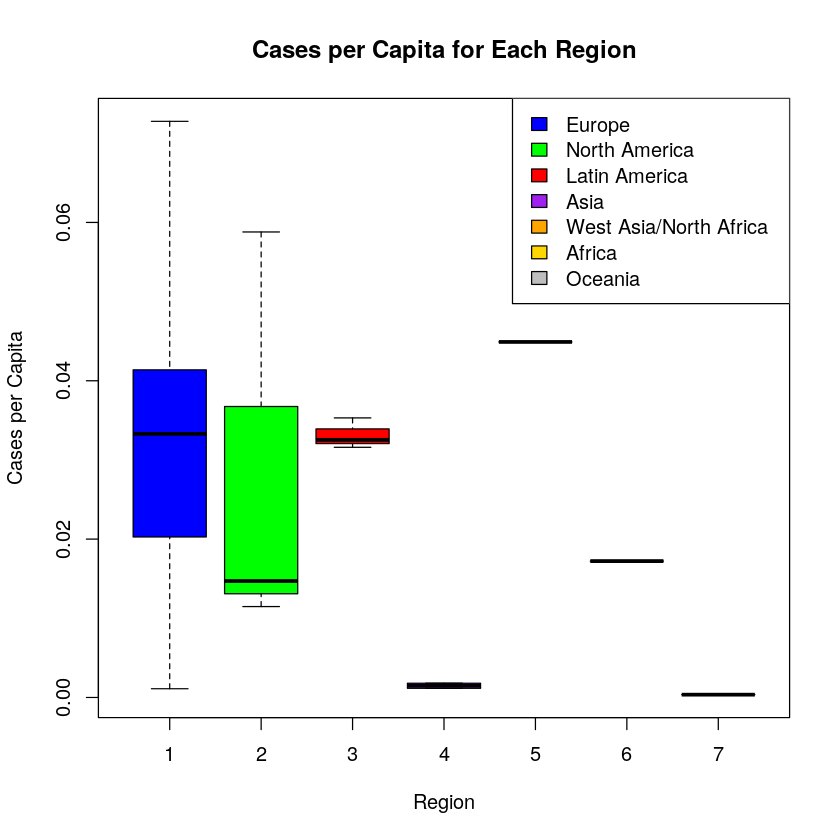

```r
boxplot(fullset[,7]~fullset[,9], main = "Cases per Capita for Each Region", col = c("blue", "green", "red", "purple", "orange", "gold1", "grey"), ylab ="Cases per Capita", xlab = "Region")
    legend("topright", c("Europe", "North America", "Latin America", "Asia", "West Asia/North Africa", "Africa", "Oceania"), border="black", fill = c("blue", "green", "red", "purple", "orange", "gold1", "grey"))
```

The clearest observation that can be made from this plot is that five of the possible seven regions are lacking in data points. This is because the anual doctor visists per country data is considerably Eurocentric, with 30 of the 41 countries included coming from Europe. With only 3 from North America, 3 from Latin America, 2 from Asia, with 1 country from West Asia, Africa, and Oceania each. Here we can see that the per region median for cases per capita for Europe and Latin America are relatively similar, where as North America has a lower median. While analysis of variance modeling does display some statistically significant variance, there are not enough data points to compare cases per capita between region.

```r
summary(aov(cases_per_capita~ Region, data = fullset))
```

```
            Df   Sum Sq   Mean Sq F value Pr(>F)
Region       1 0.001401 0.0014009   4.587 0.0385 *
Residuals   39 0.011911 0.0003054
---
Signif. codes:  0 ‘***’ 0.001 ‘**’ 0.01 ‘*’ 0.05 ‘.’ 0.1 ‘ ’ 1
```

```r
nrow(fullset[fullset$Region == 1,])
nrow(fullset[fullset$Region == 2,])
nrow(fullset[fullset$Region == 3,])
nrow(fullset[fullset$Region == 4,])
```

30

3

3

2

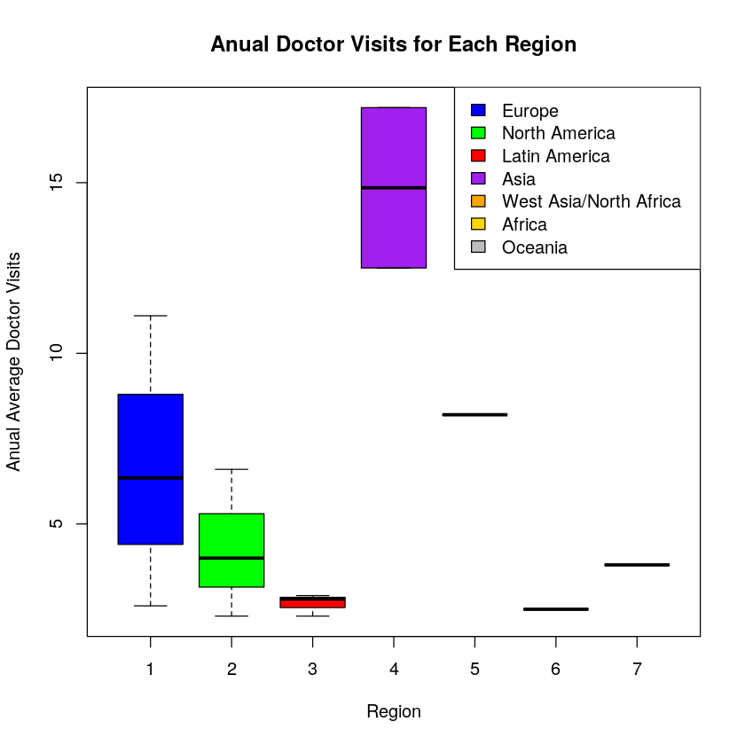

```r
boxplot(fullset[,5]~fullset[,9], main = "Anual Doctor Visits for Each Region", col = c("blue", "green", "red", "purple", "orange", "gold1", "grey"), ylab= "Anual Average Doctor Visits", xlab = "Region")
legend("topright", c("Europe", "North America", "Latin America", "Asia", "West Asia/North Africa", "Africa", "Oceania"), border="black", fill = c("blue", "green", "red", "purple", "orange", "gold1", "grey"))
```

Here we see significant variation of anual doctor visits per region, with the two asian countries, Japan and South Korea posting a median of 14.85 anual doctor visits per citizen. In comparison Europe has a median of 6.35 anual doctor visits, North America 4 anual doctor visits, and Latin America 2.8 doctor visits. Analysis of variance does not detect significant difference in mean doctor visits per region, and , as with cases per capita, there are not enough data points outside of Europe for fair analysis. This information does not warrant further investigation of the interaction between anual doctor visits and cases per capita in individual regions. In the sensitivity analysis section we will also isolate only European countries in addition to a full model including all regions, to see if there is any difference in correlation between variables in Europe and all regions.

```r
(17.2+12.5)/2
```

14.85

```r
fullset[which(fullset$Region == 4),]
```

A data.frame: 2 × 10

|  | iso3c <chr> | code <chr> | country <chr> | year <int> | value <dbl> | deaths_per_capita <dbl> | cases_per_capita <dbl> | GDP_per_capita <dbl> | Region <int> | fatality <dbl> |
| --- | --- | --- | --- | --- | --- | --- | --- | --- | --- | --- |
| 24 | JPN | JP | Japan | 2018 | 12.5 | 2.661400e-05 | 0.001800724 | 40193.25 | 4 | 0.01477961 |
| 25 | KOR | KR | South Korea | 2019 | 17.2 | 1.697548e-05 | 0.001154004 | 31631.47 | 4 | 0.01471007 |

```r
median(fullset[which(fullset$Region == 4),5])
```

14.85

```r
median(fullset[which(fullset$Region == 3),5])
```

2.8

```r
median(fullset[which(fullset$Region == 2),5])
```

4

```r
median(fullset[which(fullset$Region == 1),5])
```

6.35

```r
summary(aov(value~ Region, data = fullset))
```

```
            Df Sum Sq Mean Sq F value Pr(>F)
Region       1    0.8   0.758    0.07  0.793
Residuals   39  424.6  10.888
```

## Inferential Analysis

#### Multiple Linear Regression

Multiple linear regression tests the relationship between a continuous response variable, and multiple explanatory variables. Specifically linear regression models a linear relationship using the response variables to create a linear predictive model which minimizes error varaince. The primary of question of interest is whether the number of anual doctors' consultations per capita, prior to the outbreak of the COVID-19 pandemic, had any correlation on a particular country's cumulative number of COVID-19 cases in 2020. The secondary question of interest is whether a country's Gross Domestic Product (GDP) per capita, was predictive of cumulative COVID-19 cases in that country in 2020. Multiple linear regression allows for the measurement of the linear correlation between the variables within our questions of interest. Based on the scatter plot of the four variables, there was little evidence of a non-linear relationship, and so linear regression should be a suitable model to test for correlation between variables. This model allows for hypothesis testing, or F-testing, which can reject any linear correlation between COVID-19 cases or deaths per capita, number of medical visits and GDP per capita. We'll use the model:

$$ Y_{i}=\beta_0 +\beta_1 X_{1,i}+\beta_2 X_{2,i} + \beta_3 X_{1,i} X_{2,i} +\epsilon_{i} for \quad i=1,\ldots, 41, $$

where $\{\epsilon_{ij}\}$ are i.i.d. $N(0,\sigma^2)$.

Where $ Y_{i} $ represents the per capita COVID-19 case rate of the ith country, $ X_{1,i} $ is the anual number of doctors' consultations per capita for the ith country, $ X_{2,i} $ is the GDP per capita of the ith country. $ \beta_0 $ represent the intercept of the linear model, the predicted per capita ratio of COVID-19 cases when doctors' consultations and GDP per capita is held to zero. $ \beta_1 $ is the regression coefficient for $ X_{1,i} $, which represents the change in per capita COVID-19 cases when anual doctor's consultations increase by 1 visit, when GDP is held to 0. $ \beta_2 $ is the regression coefficient for $ X_{2,i} $, which represents the change in per capita COVID-19 cases when GDP per capita increase by 1 unit when number of Dr. consultations' is held to 0. $\epsilon_{i}$ is the minimized statistical error term, which represents the difference between the predicted model and the actual COVID-19 case rate, $ Y_{i} $ .

#### Interaction Term

The model above includes an interaction effect. An interaction effect acounts for the dependency of one regressor on another. If the response of variable X1 is dependent on the value of X2, then there will be different effects of X1 on $ Y_{i} $. In this analysis, a country's GDP per capita might impact effect that anual doctors' consultations might have on the COVID-19 case rate. We expect that countries with higher GDP per capita will be more likely to have larger numbers of anual doctors' consultations, and that countries with higher GDP will also have more medical resources so that these visits will be more impactful on a individual's health. Therefore we must test for an interaction between GDP per capita and anual doctors' consultations.

$ \beta_3$ represents the coefficient of the interaction term, showing the joint effect of Dr. consultations' and GDP per capita on COVID-19 cases per capita. Interpreting the model coefficients with the interaction term included gives us that the effect of $ X_{1,i} $, the anual number of doctors' consultations per capita for the ith country, on $Y_{i}$, COVID-19 cases per capita, is $ \beta_1 + \beta_3X_{2,i}$. The effect of $ X_{2,i} $, the GDP per capita for the ith country, on $Y_{i}$, COVID-19 cases per capita, is $ \beta_2 + \beta_3X_{1,i}$.

To test whether an interaction term is necessary, we can plot the relationship between the COVID-19 case rate, and number of Dr consultations at differing levels of GDP per capita. This will display whether changes to GDP affects the relationship between case rate and Dr consultations.

```r
install.packages('jtools')
```

```r
library('jtools') # for summ()
```

```r
fiti <- lm(cases_per_capita ~ value * GDP_per_capita, data = fullset)
```

```r
#install.packages('interactions')
library('interactions')
```

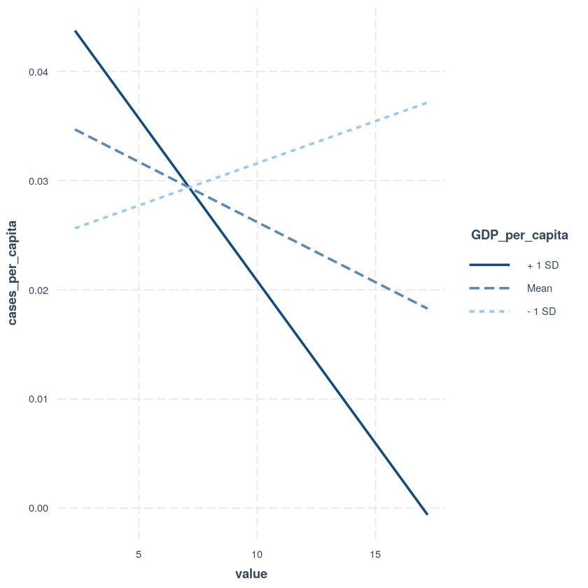

```r
interact_plot(fiti, pred = value, modx = GDP_per_capita)
```

The interaction plot displays that the relationship between COVID-19 case rate and dr visits differs depending on the GDP per capita, measured by spliting GDP into three categories, the mean of all country GPD, and issolating GDP's 1 standard deviation above and bellow the mean. These three linear relationships differ significantly in slope indicating that GDP per capita does affect the relationship of COVID-19 cases and number of Dr consultations. According to the plot, among wealthier nations, dr consultations have a negative correlation with the COVID-19 case rate, while for poorer nations, there is a positive correlation. Therefore, the interaction term will be included in the model.

### Assumptions of Multiple Linear Regression

The multiple linear regression model makes several key assumptions, denoted by $\{\epsilon_{ij}\}$ are i.i.d. $N(0,\sigma^2)$.

$\{\epsilon_{ij}\}$ are i.i.d. $N(0,\sigma^2)$ refers to the assumption that the errors, the difference between the predicted value and observed value of COVID-19 cases per capita, are independent and indentically distributed, following a normal distribution with mean 0 and standard devation of $ \sigma^2 $.

#### Linearity

Primarily, multiple linear regression assumes that there is a linear correlation between response and dependent varaibles. Based of previous scatter plots, the existence of such a relationship is unclear. However, the primary question of interest is to test the existance of a linear relationship between COVID-19 case rate and number of Dr consultations. Modeling which fails to find a significant linear relationship still allows for the rejection of primary hypothesis.

#### Independence

One of the assumptions of linear regression is that each data point is independent. However in this case, a country's response to COVID-19 may not be independent from other countries, as neighboring states may have taken COVID-19 policy cues from each other, or shared policy like the EU travel restriction, which then might have influenced the cumulative COVID-19 case numbers or deaths to be dependent with each other. For this reason, we investigated the relationship between cumulative COVID-19 cases and region, to see if neighboring countries shared common case numbers which differed from other regions. However there were not enough countries from different regions to accurately conduct such analysis. This assumption is difficult to fix through transformation, so we must continue the analysis despite risk of error, while also examining a linear regression model containing only European countries.

#### Multicollinearity

Multiple linear regression also assumes that the variables have no multicollinearity. This means that the response variables, Dr consultation and GDP per capita should not have a high correlation with each other. Judging by the intitial scatterplot of variables, there is no obvious linear correlation between these variables.

#### Homoscedasticity

Another assumption is that the error terms are identically distributed, also known as homoscedasticity. The current data statisfies this assumption according to the Scale-Location v. Standardize Residuals plot, which shows a horizontal spread of data without apparent pattern.

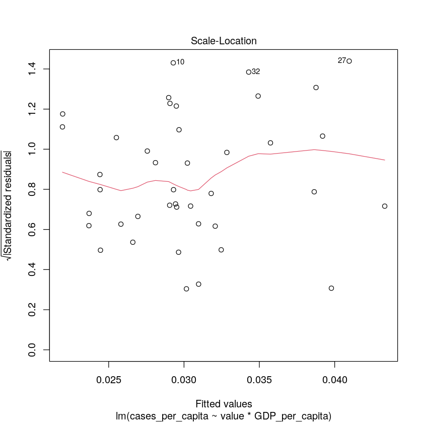

```r
# constant variance check
casemodel = lm(cases_per_capita ~ value*GDP_per_capita , data=fullset)
plot(casemodel, 3)
```

#### Normality

The final assumption is that the errors follow a normal distribution. This can be determined visually using a Normal-QQ plot which compares the standardized residuals to quantiles from a normal distribution. If the residuals correlate with the normal quantiles, then a straight line will be formed. Judging the Normal Q-Q plot below, there is some deviation from the normal distribution, along the right edge of the graph, however the residuals still follow a relative normal distribution. This model appears to have a residual distribution close enough to the normal distribution to leave results unskewed, however this will be investigated further in sensitivity analysis.

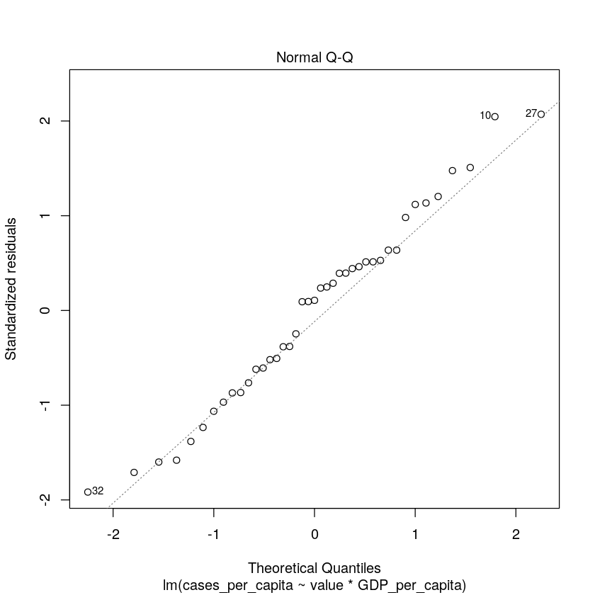

```r
# linearity
plot(casemodel, 2)
```

### Results

#### COVID-19 Cases per Capita as Response Variable

```r
casemodel = lm(cases_per_capita ~ value*GDP_per_capita , data=fullset)
summary(casemodel)
```

```
Call:
lm(formula = cases_per_capita ~ value * GDP_per_capita, data = fullset)

Residuals:
      Min        1Q    Median        3Q       Max
-0.033941 -0.012941  0.001806  0.009376  0.036366

Coefficients:
                       Estimate Std. Error t value Pr(>|t|)
(Intercept)           1.757e-02  1.156e-02   1.520    0.137
value                 1.656e-03  1.927e-03   0.859    0.396
GDP_per_capita        5.392e-07  3.447e-07   1.564    0.126
value:GDP_per_capita -7.565e-08  6.208e-08  -1.219    0.231

Residual standard error: 0.01817 on 37 degrees of freedom
Multiple R-squared:  0.08245,	Adjusted R-squared:  0.008059
F-statistic: 1.108 on 3 and 37 DF,  p-value: 0.358
```

Adding these coefficients changes the model from

$ Y_{i}=\beta_0 +\beta_1 X_{1,i}+\beta_2 X_{2,i} + \beta_3 X_{1,i} X_{2,i} +\epsilon_{i} $

To

$ Y_{i}=0.018 + 0.002X_{1,i}+ 0.0000005X_{2,i} - 0.00000008X_{1,i} X_{2,i} +\epsilon_{i} $

$ \beta_0 $ = 0.018, represent the intercept of the linear model, the predicted per capita ratio of COVID-19 cases when doctors' consultations and GDP per capita is held to zero. $ \beta_3$ = -0.00000008 represents the coefficient of the interaction term, showing the joint effect of Dr. consultations' and GDP per capita on COVID-19 cases per capita. The effect of $ X_{1,i} $, the anual number of doctors' consultations per capita for the ith country, on $Y_{i}$, COVID-19 cases per capita, is 0.002 - 0.00000008 $X_{2,i}$, where $X_{2,i}$ represents the GDP per capita of the ith country. The effect of $ X_{2,i} $, the GDP per capita for the ith country, on $Y_{i}$, COVID-19 cases per capita, is 0.0000005 - 0.00000008$X_{1,i}$.

However these coefficients are not necessarily significant. To determine whether these coefficients actually create a model which predicts COVID-19 cases per capita with high accuracy, we must conduct F-tests, or hypothesis tests. For these hypothesis tests we will use a significance level, $ \alpha$ = 0.01, which sets the likelihood of incorrectly rejecting the null hypothesis.

#### F-test for $ \beta_0$

The null hypothesis is $$ H_0: \beta_0 =0 $$

$$ H_1: \beta_0 does\ not\ equal\ 0 $$

Because the P-value of $\beta_0$ = 0.137 which is greater than $\alpha$ = 0.01, we cannot reject the null hypothesis that $$ H_0: \beta_0 =0 $$ .

#### F-test for $ \beta_1$

The null hypothesis is $$ H_0: \beta_1 =0 $$

$$ H_1: \beta_1 does\ not\ equal\ 0 $$

Because the P-value of $\beta_1$ = 0.396 which is greater than $\alpha$ = 0.01, we cannot reject the null hypothesis that $$ H_0: \beta_0 =0 $$ .

#### F-test for $ \beta_2$

The null hypothesis is $$ H_0: \beta_2 =0 $$

$$ H_1: \beta_2 does\ not\ equal\ 0 $$

Because the P-value of $\beta_2$ = 0.126 which is greater than $\alpha$ = 0.01, we cannot reject the null hypothesis that $$ H_0: \beta_0 =0 $$ .

#### F-test for $ \beta_3$

The null hypothesis is $$ H_0: \beta_3 =0 $$

$$ H_1: \beta_2 does\ not\ equal\ 0 $$

Because the P-value of $\beta_3$ = 0.231 which is greater than $\alpha$ = 0.01, we cannot reject the null hypothesis that $$ H_0: \beta_0 =0 $$ .

Following these F-tests, we must conclude that none of the coefficients in the model are statistically significant. This means that our model failed to find any linear correlation between the response variable COVID-19 cases per capita, anual doctors' consultations per capita, and GDP per capita. The Multiple R-squared metric represents the amount of variation in COVID-19 cases per capita that was explained by the regressors dr consultations and GDP per capita. The Multiple R-squared was 0.08245, indicating that the independent variables explaned almost none of the variation found in Cases per capita. Even the interaction between dr consultations and GDP per capita is insignificant statistically, showing that there was no joint effect of both dr consultations and GDP per capita on cases measured among the data set.

This data indicates that other factors, possibly the stringency of lockdown measures taken by countries, were far more predictive the of COVID-19 case rate in 2020 than doctors' consultations prior to COVID-19 or a nation's GDP per capita.

#### COVID-19 Deaths per Capita as Response Variable

There was insignificant linear regression predicted by dr consultations and GDP per capita when cases per capita was used as the response variable. However the ratio of COVID-19 deaths per capita also serves as a measure of COVID-19 outcome, one that could be effected by the level of medical care prior to the pandemic, or by GDP per capita. To test this we can use the same multiple linear regression model, with deaths per capita as the response variable.

```r
deathmodel = lm(deaths_per_capita ~ value*GDP_per_capita , data=fullset)
summary(deathmodel)
```

```
Call:
lm(formula = deaths_per_capita ~ value * GDP_per_capita, data = fullset)

Residuals:
       Min         1Q     Median         3Q        Max
-6.738e-04 -3.455e-04 -4.112e-05  2.731e-04  1.130e-03

Coefficients:
                       Estimate Std. Error t value Pr(>|t|)
(Intercept)           7.828e-04  2.751e-04   2.845   0.0072 **
value                -1.388e-05  4.588e-05  -0.303   0.7639
GDP_per_capita        2.586e-11  8.206e-09   0.003   0.9975
value:GDP_per_capita -3.328e-10  1.478e-09  -0.225   0.8231
---
Signif. codes:  0 ‘***’ 0.001 ‘**’ 0.01 ‘*’ 0.05 ‘.’ 0.1 ‘ ’ 1

Residual standard error: 0.0004326 on 37 degrees of freedom
Multiple R-squared:  0.04086,	Adjusted R-squared:  -0.03691
F-statistic: 0.5254 on 3 and 37 DF,  p-value: 0.6676
```

#### F-test for $ \beta_0$

The null hypothesis is $$ H_0: \beta_0 =0 $$

$$ H_1: \beta_0 does\ not\ equal\ 0 $$

Because the P-value of $\beta_0$ = 0.0072 which is less than $\alpha$ = 0.01, we can reject the null hypothesis that $$ H_0: \beta_0 =0 $$ .

#### F-test for $ \beta_1$

The null hypothesis is $$ H_0: \beta_1 =0 $$

$$ H_1: \beta_1 does\ not\ equal\ 0 $$

Because the P-value of $\beta_1$ = 0.7639 which is greater than $\alpha$ = 0.01, we cannot reject the null hypothesis that $$ H_0: \beta_0 =0 $$ .

#### F-test for $ \beta_2$

The null hypothesis is $$ H_0: \beta_2 =0 $$

$$ H_1: \beta_2 does\ not\ equal\ 0 $$

Because the P-value of $\beta_2$ = 0.9975 which is greater than $\alpha$ = 0.01, we cannot reject the null hypothesis that $$ H_0: \beta_0 =0 $$ .

#### F-test for $ \beta_3$

The null hypothesis is $$ H_0: \beta_3 =0 $$

$$ H_1: \beta_2 does\ not\ equal\ 0 $$

Because the P-value of $\beta_3$ = 0.8231 which is greater than $\alpha$ = 0.01, we cannot reject the null hypothesis that $$ H_0: \beta_0 =0 $$ .

With the exception of the intercept $ \beta_0$, none of the other coefficients were found to be statistically significant. This indicates that COVID-19 deaths per capita has no correlation with dr consultations or GDP per capita, and is actually a worse response variable as its multiple R-squared is 0.04086, half of the previous R-squared.

## Sensitivity Analysis

#### COVID-19 Cases per Capita as Response Variable

In sensitivity analysis we investigate the accuracy of the linear model used where COVID-19 Cases per Capita was a response variable to dr consultations and GDP per capita. This model found little correlation between variables, and could not establish a statistically significant linear relationship. In sensitivity analysis, we will check the assumptions made to ensure that the correct model was used and no assumptions were violated. If the assumptions are found to be valid, then we must accept that the model accurately found no correlation between variables in the data set.

#### Linearity

Multiple linear regression assumes that there is a linear correlation between response and dependent varaibles. Linearity can be displayed using a Residuals v. Fitted Values plot, which if linearity holds should display a horizontal spread of data points without a clear pattern of variation.

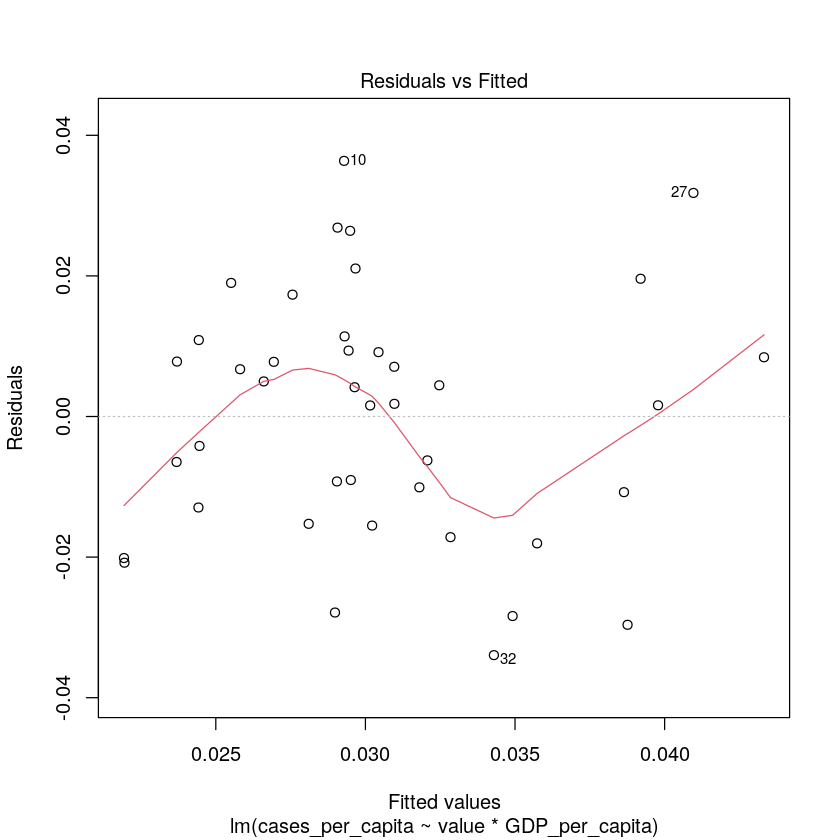

```r
plot(casemodel,1)
```

This model does show horizontal spread, however there appears to be some bend in the residual values, indicating that there might not be a linear distribution.

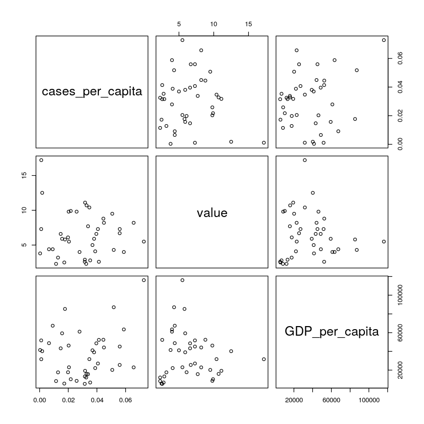

```r
plot(fullset[,c("cases_per_capita","value", "GDP_per_capita")])
```

Likewise, from the scatterplot above, it is unclear whether a linear, or non-linear relationship can be drawn between variables. As our model failed to find any linear relationship, this can be expected. However, we can actually ignore the linearity assumption of multiple linear regression, provided that the residuals prove to be normally distributed and homoscedastic. These assumptions will be tested instead of linearity.

#### Homoscedasticity

When outlining our assumptions we displayed the Scale-Location v. Standardize Residuals plot, which should show a horizontal spread of data without apparent pattern if the residuals have constant varaince. The Scale-Location v. Standardize Residuals plot using COVID-19 data did display a seemingly random spread of standardized residuals. However, to test this assumption we use the studentized Breusch-Pagan test. The studentized Breusch-Pagan test sets a Null Hypothesis $$ H_0: data\ is \ Homoscedastic\ $$

And an Alternative Hypothesis: $$ H_1: data\ is \ Heteroscedastic\ $$

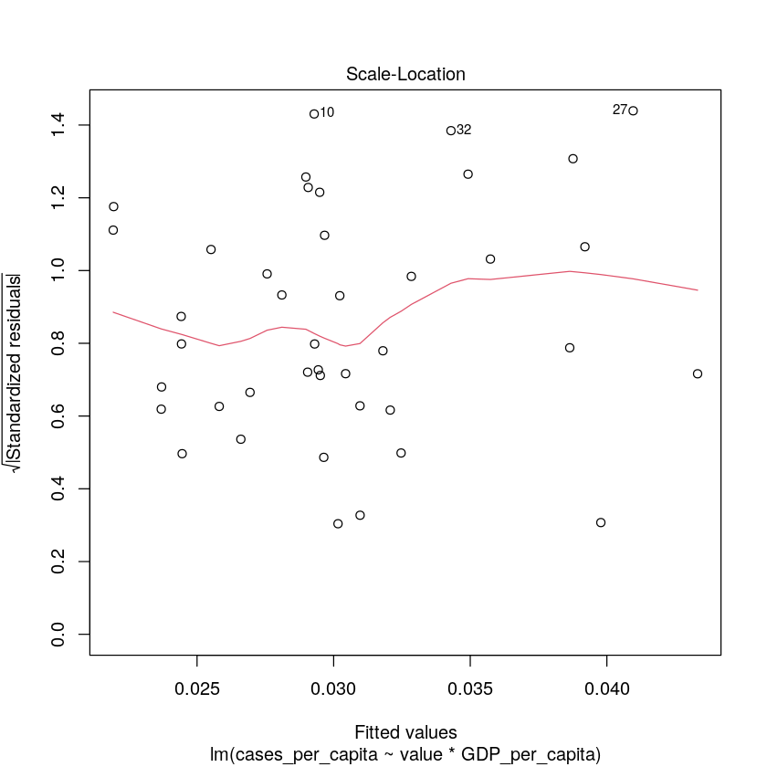

```r
plot(casemodel, 3)
```

```r
install.packages('car')
```

```r
library(lmtest)
bptest(casemodel)
```

```
	studentized Breusch-Pagan test

data:  casemodel
BP = 6.2008, df = 3, p-value = 0.1022
```

Using this test we find a p-value = 0.1022. For this test we will continue to use an alpha level of 0.01. Therefore, we fail to reject the null hypothesis, using a significance level of 0.01, that the residuals are homoscedastic.

While this test does not guarantee that our residuals are not heteroscedastic, but as the p-value was quite large, we can be confident that our model does not fail the homoscedasticity requirement for accuracy.

#### Normality

Linear regression assumes that the residuals follow a normal distribution. This can be determined visually using a Normal-QQ plot which compares the standardized residuals to quantiles from a normal distribution. If the residuals correlate with the normal quantiles, then a straight line will be formed. In our Normal-QQ plot there is some deviation from the normal distribution, along the right edge of the graph, however the residuals still follow a relative normal distribution.

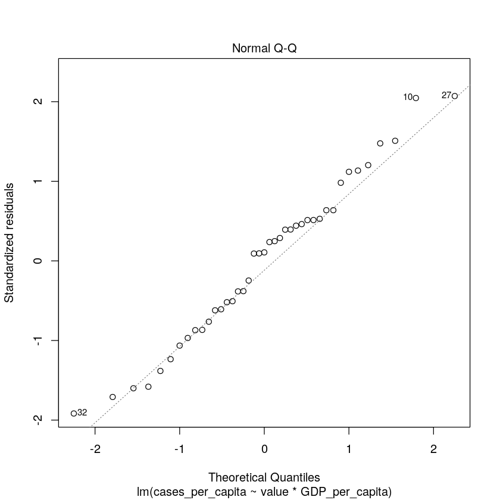

```r
plot(casemodel,2)
```

To test whether our residuals follow a normal distribution, we must conduct a Shapiro-Wilks Normality Test, which sets a Null Hypothesis: $$ H_0: data\ is \ normally \ distributed\ $$ And an Alternative Hypothesis: $$ H_1: data\ is\ not \ normally \ distributed\ $$

```r
library(MASS)
resid <- studres(casemodel)
shapiro.test(resid)
```

```
	Shapiro-Wilk normality test

data:  resid
W = 0.98065, p-value = 0.7
```

Using the Shapiro-Wilk normality test, we fail to reject the Null Hypothesis, that the errors are normally distributed, at a significance level of 0.01. The P-value is 0.7 which is greater than any useful alpha, between 0.05-0.01. From this we can conclude that it is highly likely that the residuals of the linear regression model follow a relatively normal distribution, satisfy the regression assumption.

#### Linearity

Revisting the linearity assumption, while a linear relationship between variables COVID-19 cases per capita, doctors' constultations per capita, and GDP per capita may not exist, because the residuals follow a normal distribution with constant variance this assumption can be ignored.

#### Independence

A country's response to COVID-19 may not be independent from other countries, as neighboring states may have taken COVID-19 policy cues from each other which might have influenced the cumulative COVID-19 case numbers or deaths to be dependent with each other. For this reason, we investigated the relationship between cumulative COVID-19 cases and region, to see if neighboring countries shared common case numbers which differed from other regions. However there were not enough countries from different regions to accurately conduct such analysis. We will conduct a seperate linear regression model of only European countries to see if there is any change in the relationship of variables, in comparisson to a model with multiple regions.

However, we can also test for the correlation between residuals by using a Durbin-Watson Test. A Durbin-Watson Test looks for autocorrelation within the data, essentially comparing the residuals to themselves. If there is autocorrelation, than there is not independence.

Null Hypothesis: $$ H_0: data\ is \ not \ autocorrelated\ $$ And an Alternative Hypothesis: $$ H_1: data\ is\ autocorrelated\ $$

```r
install.packages("lmtest")
library("lmtest")
```

```r
dwtest(casemodel)
```

```
	Durbin-Watson test

data:  casemodel
DW = 1.8898, p-value = 0.3289
alternative hypothesis: true autocorrelation is greater than 0
```

Using a significance level of 0.01, we fail to reject the null hypothesis that there is no autocorrelation, as the p-value = 0.3289. This test indicates that the model does not violate the independence assumption.

#### Multicollinearity

Multiple linear regression also assumes that the variables have no multicollinearity. This means that the response variables, Dr consultation and GDP per capita should not have a high correlation with each other. Judging by the intitial scatterplot of variables, there is no obvious linear correlation between these variables.

First we construct a correlation mattrix which displays the level of correlation between each of the variables used in the model. Variables should have a perfect correlation of 1 with themselves.

```r
expVar = fullset[,c("cases_per_capita","value","GDP_per_capita")]
corMatrix <- round(cor(expVar), 2)
corMatrix
```

A matrix: 3 × 3 of type dbl

|  | cases_per_capita | value | GDP_per_capita |
| --- | --- | --- | --- |
| cases_per_capita | 1.00 | -0.09 | 0.20 |
| value | -0.09 | 1.00 | -0.05 |
| GDP_per_capita | 0.20 | -0.05 | 1.00 |

To check whether the variables are multicollinear, we can conduct a Farrar - Glauber Test for Multicollinearity.

```r
install.packages("mctest")
```

```r
is.atomic(fullset)
```

FALSE

```r
cases = fullset[,6]
```

```r
# collinearity using mctest
library(mctest)
imcdiag(casemodel)
```

```
Call:
imcdiag(mod = casemodel)


All Individual Multicollinearity Diagnostics Result

                         VIF    TOL       Wi       Fi Leamer    CVIF Klein
value                 4.7835 0.2091  71.8872 147.5578 0.4572  4.6225     1
GDP_per_capita        8.8456 0.1131 149.0660 305.9776 0.3362  8.5477     1
value:GDP_per_capita 12.0722 0.0828 210.3718 431.8159 0.2878 11.6657     1
                       IND1   IND2
value                0.0110 0.9144
GDP_per_capita       0.0060 1.0253
value:GDP_per_capita 0.0044 1.0603

1 --> COLLINEARITY is detected by the test
0 --> COLLINEARITY is not detected by the test

value , GDP_per_capita , value:GDP_per_capita , coefficient(s) are non-significant may be due to multicollinearity

R-square of y on all x: 0.0825

* use method argument to check which regressors may be the reason of collinearity
===================================
```

The Farrar - Glauber Test for Multicollinearity, indicates that there is Multicollinearity between all variables used in the regression model. However this is not supported by any visible correlation between the scatter plots of dr consultations and GDP per capita. To verrify if there is multicollinearity, we must check the p-values of relationship between suspect multicollinear variables.

```r
install.packages("ppcor")
```

```r
library("ppcor")
pcor(expVar, method = "pearson")
```

**$estimate**

A matrix: 3 × 3 of type dbl

|  | cases_per_capita | value | GDP_per_capita |
| --- | --- | --- | --- |
| cases_per_capita | 1.00000000 | -0.07860804 | 0.19583143 |
| value | -0.07860804 | 1.00000000 | -0.03413332 |
| GDP_per_capita | 0.19583143 | -0.03413332 | 1.00000000 |

**$p.value**

A matrix: 3 × 3 of type dbl

|  | cases_per_capita | value | GDP_per_capita |
| --- | --- | --- | --- |
| cases_per_capita | 0.0000000 | 0.6297042 | 0.2258799 |
| value | 0.6297042 | 0.0000000 | 0.8343753 |
| GDP_per_capita | 0.2258799 | 0.8343753 | 0.0000000 |

**$statistic**

A matrix: 3 × 3 of type dbl

|  | cases_per_capita | value | GDP_per_capita |
| --- | --- | --- | --- |
| cases_per_capita | 0.0000000 | -0.4860766 | 1.2310216 |
| value | -0.4860766 | 0.0000000 | -0.2105346 |
| GDP_per_capita | 1.2310216 | -0.2105346 | 0.0000000 |

**$n**

41

**$gp**

1

**$method**

'pearson'

As the p-values of the correlation between respective varaibles were 0.8343753, 0.629704, and 0.2258799 we fail to reject the null hypothesis, at significance level a=0.01, that the varaibles are not multicollinear. Therefore the linear regression model does not fail the multicollinearity assumption.

#### COVID-19 Fatality Rate per Capita as Response Variable

By dividing cumulative COVID-19 deaths by case numbers, we can find the fatality rate, the percentage of those infected with COVID-19 who died. By using this as a response, we look for any relationship between dr consultations and GDP per capita and the likelyhood of COVID-19 being fatal per country.

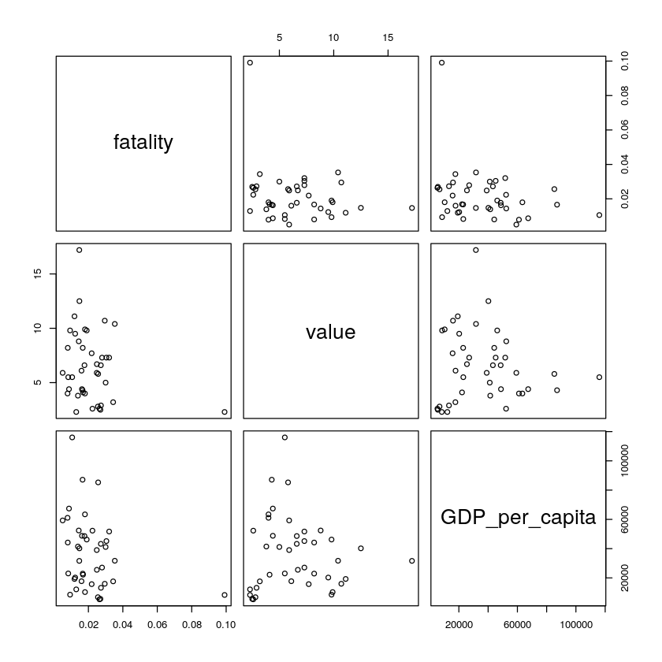

```r
plot(fullset[,c("fatality",'value','GDP_per_capita')])
```

```r
fatmodel = lm(fatality ~ value*GDP_per_capita , data=fullset)
summary(fatmodel)
```

```
Call:
lm(formula = fatality ~ value * GDP_per_capita, data = fullset)

Residuals:
      Min        1Q    Median        3Q       Max
-0.020544 -0.007935 -0.003115  0.004948  0.064063

Coefficients:
                       Estimate Std. Error t value Pr(>|t|)
(Intercept)           4.603e-02  8.756e-03   5.257 6.36e-06 ***
value                -3.312e-03  1.460e-03  -2.268   0.0292 *
GDP_per_capita       -5.881e-07  2.612e-07  -2.252   0.0304 *
value:GDP_per_capita  7.893e-08  4.704e-08   1.678   0.1018
---
Signif. codes:  0 ‘***’ 0.001 ‘**’ 0.01 ‘*’ 0.05 ‘.’ 0.1 ‘ ’ 1

Residual standard error: 0.01377 on 37 degrees of freedom
Multiple R-squared:  0.2017,	Adjusted R-squared:  0.137
F-statistic: 3.117 on 3 and 37 DF,  p-value: 0.03764
```

Examining the P-values of the coefficients in the model indicates that dr consultations and GDP per capita were far better at predicting the fatality rate of a country than its cases or deaths per capita. However when conducting F-tests using the same alpha level as before, 0.01, we still fail to reject the null hypothesis. $$ H_0: \beta_1=\beta_2=\beta_3 =0 $$

Using a significance level of 0.05, we can reject the null hypothesis for $ \beta_1 $ and $\beta_2$. This raises the risk of faslely rejecting the null hypothesis. The multiple R-squared is 0.2017, meaning that while the independent variables were far better at predicting the fatality rate of individual countries, it still only accounted for 20% of the variation in fatality rate between countries. We're left to conclude that there may be some correlation between fatality rate, dr visits and GDP per capita at a low significance level. However there are likely more consequential factors to predict fatality rate, like availability of hospital space, and the level of medical resources available.

However, there is a clear outlier when viewing fatality rate. Mexico has the highest reported fatality rate of 0.099, meaning nearly 10% of those reported infected with COVID-19 died. This is likely the result of inacurate data reported to the WHO, as other sources give a fatality rate far below that.

##### Removing Mexico (Inaccurate Data)

```r
fullset[which.max(fullset$fatality),]
```

A data.frame: 1 × 10

|  | iso3c <chr> | code <chr> | country <chr> | year <int> | value <dbl> | deaths_per_capita <dbl> | cases_per_capita <dbl> | GDP_per_capita <dbl> | Region <int> | fatality <dbl> |
| --- | --- | --- | --- | --- | --- | --- | --- | --- | --- | --- |
| 29 | MEX | MX | Mexico | 2019 | 2.3 | 0.00113743 | 0.0114786 | 8329.271 | 2 | 0.09909133 |

```r
sub = fullset[-which.max(fullset$fatality),]
submodel = lm(fatality ~ value*GDP_per_capita , data=sub)
summary(submodel)
```

```
Call:
lm(formula = fatality ~ value * GDP_per_capita, data = sub)

Residuals:
       Min         1Q     Median         3Q        Max
-0.0133930 -0.0054007 -0.0005336  0.0051753  0.0162032

Coefficients:
                       Estimate Std. Error t value Pr(>|t|)
(Intercept)           3.026e-02  5.401e-03   5.603 2.36e-06 ***
value                -1.385e-03  8.761e-04  -1.581   0.1227
GDP_per_capita       -2.772e-07  1.558e-07  -1.780   0.0836 .
value:GDP_per_capita  3.654e-08  2.773e-08   1.317   0.1960
---
Signif. codes:  0 ‘***’ 0.001 ‘**’ 0.01 ‘*’ 0.05 ‘.’ 0.1 ‘ ’ 1

Residual standard error: 0.007987 on 36 degrees of freedom
Multiple R-squared:  0.1197,	Adjusted R-squared:  0.04633
F-statistic: 1.632 on 3 and 36 DF,  p-value: 0.1991
```

#### COVID-19 Case Rate per Capita as Response Variable in Europe

```r
euro = fullset[which(fullset$Region == 1),]
```

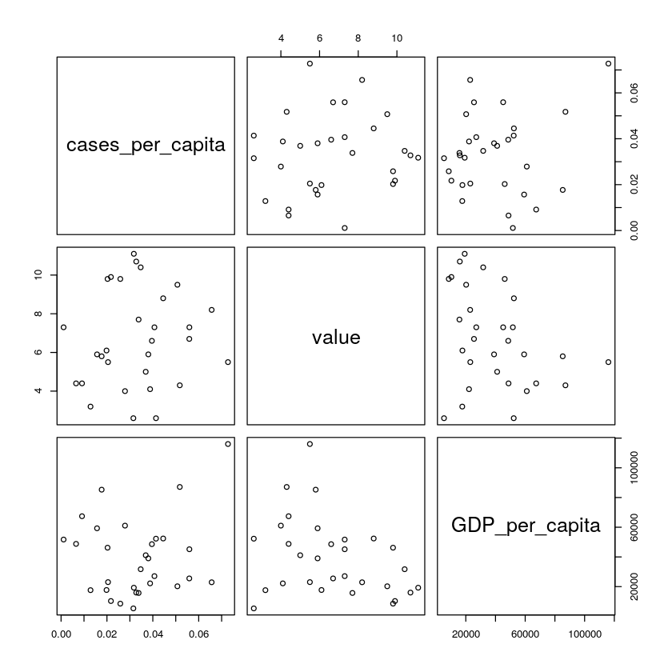

```r
plot(euro[,c("cases_per_capita",'value','GDP_per_capita')])
```

```r
euromodel = lm(cases_per_capita ~ value*GDP_per_capita , data=fullset)
summary(euromodel)
```

```
Call:
lm(formula = cases_per_capita ~ value * GDP_per_capita, data = fullset)

Residuals:
      Min        1Q    Median        3Q       Max
-0.033941 -0.012941  0.001806  0.009376  0.036366

Coefficients:
                       Estimate Std. Error t value Pr(>|t|)
(Intercept)           1.757e-02  1.156e-02   1.520    0.137
value                 1.656e-03  1.927e-03   0.859    0.396
GDP_per_capita        5.392e-07  3.447e-07   1.564    0.126
value:GDP_per_capita -7.565e-08  6.208e-08  -1.219    0.231

Residual standard error: 0.01817 on 37 degrees of freedom
Multiple R-squared:  0.08245,	Adjusted R-squared:  0.008059
F-statistic: 1.108 on 3 and 37 DF,  p-value: 0.358
```

### Conclusion

This report failed to find any significant linear correlation among three different response varaibles: 2020 COVID-19 cases per capita, 2020 COVID-19 deaths per capita, and 2020 COVID-19 fatality rate and two independent response variables: anual doctors' consultations per capita and GDP per capita. While modeling assumptions were satisfied, no correlation could be drawn using the independent variables. It is likely that other factors, like the nature of governmental response to COVID-19, were far more predictive of COVID-19 outcome. This data is supported by previous research (Mattiuzi et al, 2021) which found that "total healthcare expenditure, public sector health expenditure" had no significant correlation with the COVID-19 death rate.